# Duzenleme

Eda Emanet

10 02 2021

**Kutuphaneler**

```r
library(jsonlite)
library(MSMB)
library(tiff)
library(tiff)
library(basetheme)
library(ggCyberPunk)
library(tidyverse)
library(utf8)
library(lubridate)
library(dplyr)
library(cyberpunk)
library(ggbernie)
```

```r
library(ggplot2)
```

**Datayi Tanima** Oncellikle datayi cektik.

```r
df1<-fromJSON("son_medical.json")

df2<-fromJSON("son_bio.json")

df3 <- fromJSON("son_gene.json")

df1<- as.data.frame(df1)
df2 <- as.data.frame(df2)
data1<- data.frame(df1,df2)
```

```r
attach(df1)
df1$demographic <- df1$demographic[,-c(14:17,8)]
df1$demographic <- df1$demographic %>%
                 mutate_if(is.character,as.factor)

df1$demographic$year_of_death <-as.Date(as.character(demographic$year_of_death),format="%Y")

class(df1$demographic$year_of_death)
```

```
## [1] "Date"
```

```r
df1$demographic$year_of_birth<-as.Date(as.character(demographic$year_of_birth),format="%Y")
class(df1$demographic$year_of_birth)
```

```
## [1] "Date"
```

```r
df1$demographic <- df1$demographic[,-c(14:17,8)]


data1 <- data.frame(df1,df2)

head(df1$demographic$weight)
```

[output not shown]

```r
df4<- read_csv("C:/Users/Dell/Dropbox/My PC (DESKTOP-EB8G4PC)/Desktop/GitHub/Brain Tumor.csv")
```

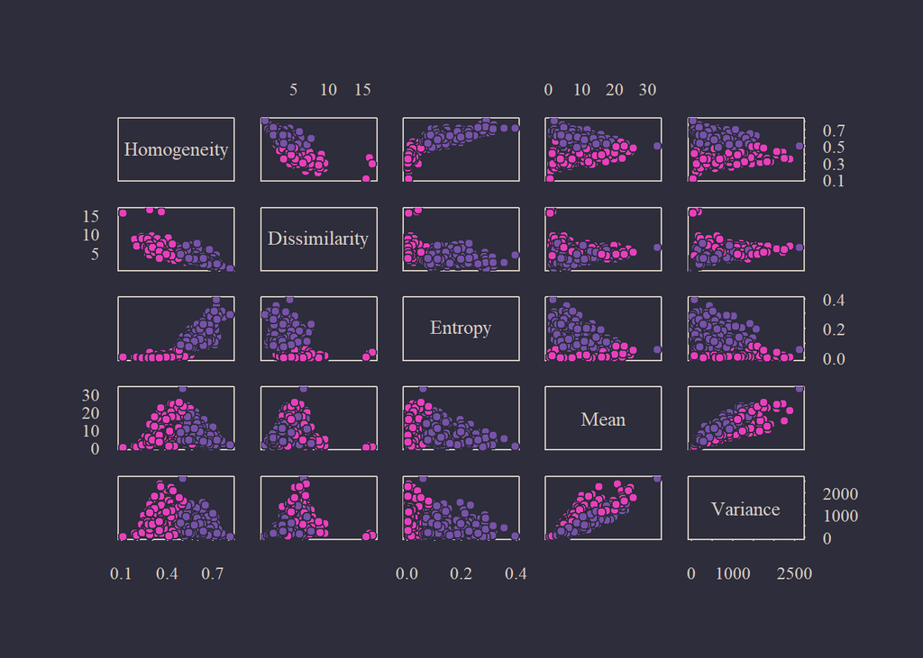

```r
d<-df4%>%
  select(Homogeneity,Dissimilarity,Entropy,Mean,Variance)


basetheme("royal")
pairs(d, bg=lab2col(df4$Class), col=0)
```

Datamizdaki mri goruntulerini daha iyi anlamak icin df4 deki dataframeden class hastaliga sahip ve sahip olmayan kisilerin mri goruntulerinin diger degiskenlerle olan iliskilerini anlamak icin grafik cizdirdik.

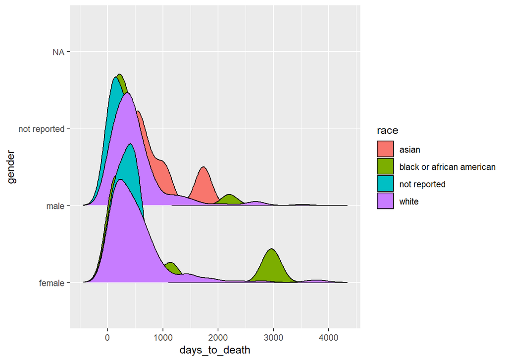

```r
library(ggplot2)
library(ggridges)
ggplot(df1$demographic, aes(x = days_to_death, y =gender,fill=race )) + geom_density_ridges()
```

Datadaki demografik degiskenlere bakmak icin grafik cizdirdik.

```r
# remotes::install_github("R-CoderDotCom/ggcats@main")


df1$demographic = mutate(df1$demographic,hastalikyas = case_when(df1$demographic$age_at_index<=17~"Ergen yas araligi",
                                            df1$demographic$age_at_index>18 & df1$demographic$age_at_index<=65~"Genc yas araligi",
                                            df1$demographic$age_at_index>66 & df1$demographic$age_at_index<=79~"Orta yas araligi",
                                            df1$demographic$age_at_index>80 & df1$demographic$age_at_index<=99~"Yasli",
                                            is.na(df1$demographic$age_at_index==TRUE)~NA_character_))

table(df1$demographic$hastalikyas)
```

```
##
## Ergen yas araligi  Genc yas araligi  Orta yas araligi             Yasli
##                 5               403               148                22
```

yaslari kendi aralarinda kategorilere ayirdik.

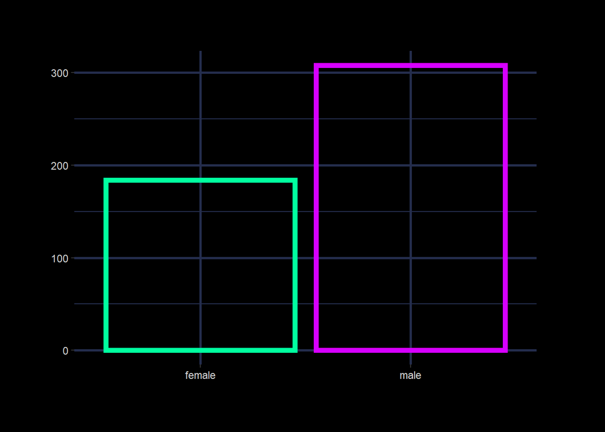

```r
df10<- df1$demographic %>%
   filter(vital_status=="Dead")%>%
  group_by(gender)%>%
  count()
df11 <- data.frame(x = df10$gender,
                 y = df10$n)

cyber_bars(df11, area = FALSE, bg.col = "black")
```

Bu kisimda olen kisilerin cinsiyetlerini anlamaya calistik.

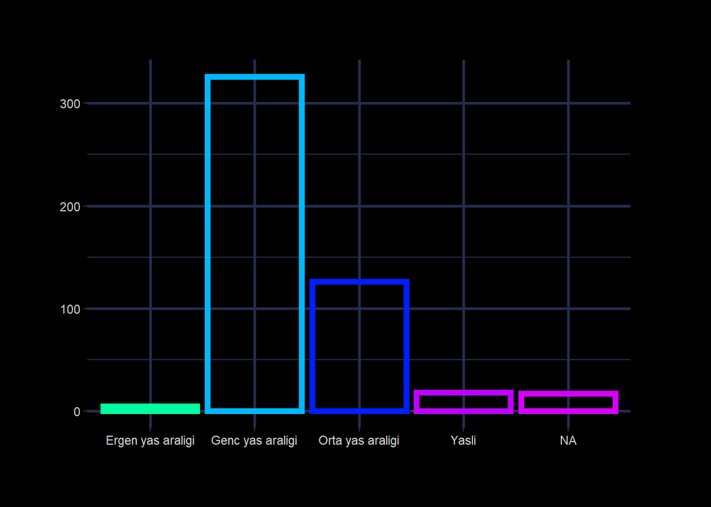

```r
df8<- df1$demographic %>%
  filter(vital_status=="Dead")%>%
  group_by(hastalikyas)%>%
  count()

df9 <- data.frame(x = df8$hastalikyas,
                 y = df8$n)

# Barplot
cyber_bars(df9, area = FALSE, bg.col = "black")
```

Bu kisimda ise hastalik yuzunden olen kisilerin yas araliklarina bakarak hangi yas araligindaki kisilerin daha cok vefat ettigini anlamaya calistik. Burada Genc yas araliginda daha cok olumu bulmak bizi sasirtti. Ama bunun sebebinin; datada gozlem sayisi olarak genc yastakilerin daha cok olmasina bagliyoruz.

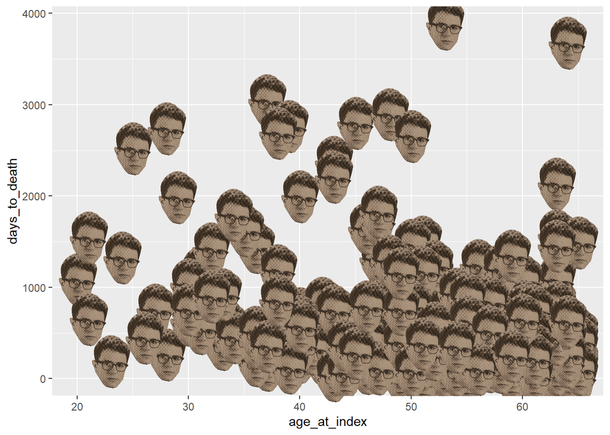

```r
genc_olum <-df1$demographic%>%
  filter(hastalikyas=="Genc yas araligi") %>%
  filter(vital_status=="Dead") %>%
  select(age_at_index,days_to_death,race,gender)
ggplot(genc_olum) +
  geom_bernie(aes(age_at_index,days_to_death), bernie = "young")
```

Burada ise genc yasta olenlerin teshisten- olumune kadar gecen surelerine baktik

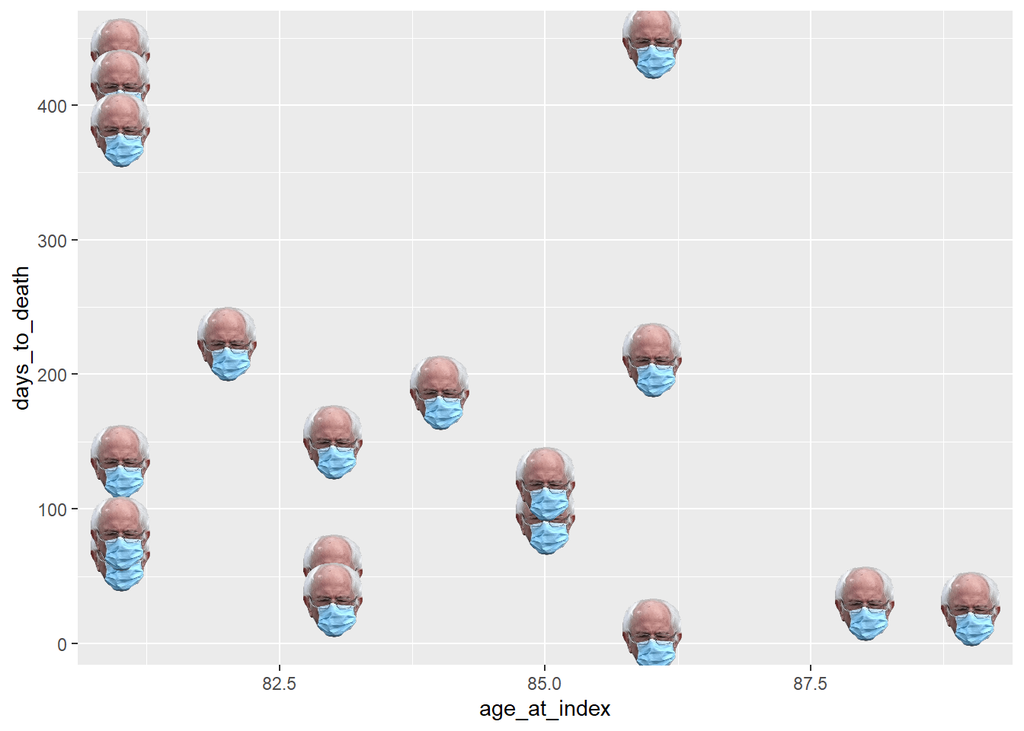

```r
yasli_olum <-df1$demographic%>%
  filter(hastalikyas=="Yasli") %>%
  filter(vital_status=="Dead") %>%
  select(days_to_death,race,gender,age_at_index)


ggplot(yasli_olum) +
  geom_bernie(aes(age_at_index,days_to_death), bernie = "head")
```

Burada ise yasli olumlerinin olume kadar gecen surelerine baktik genis bir skalada olmasi ilgimizi cekti.

[output not shown]

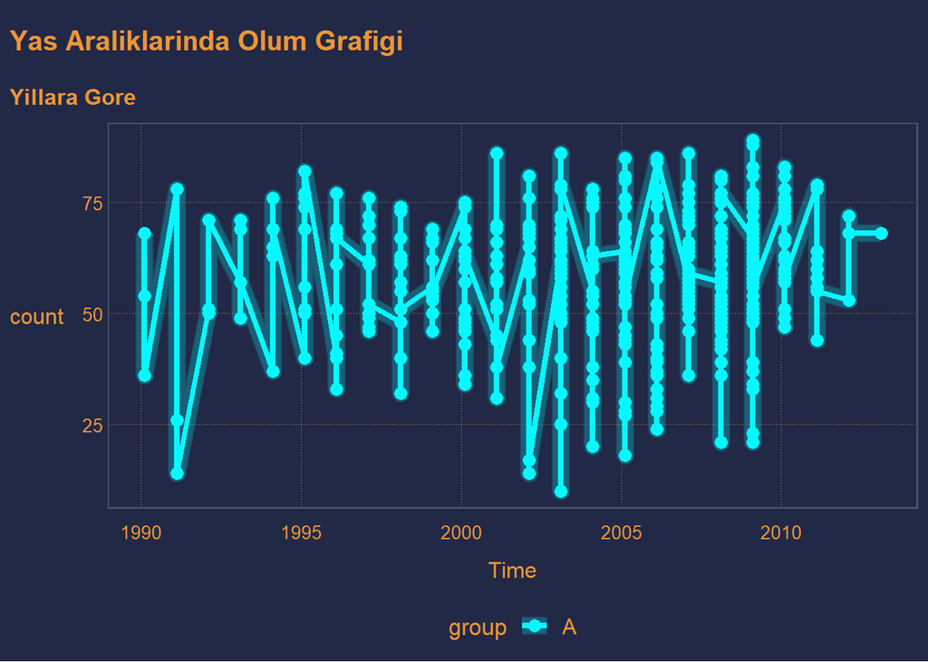

```r
df6 = data.frame(A=c(df1$demographic$age_at_index),
               Time=c(df1$demographic$year_of_deat)) %>%
pivot_longer(cols = c(A),names_to = "group", values_to = "count")


library(ggCyberPunk)
library(ggplot2)
df6 %>%
   ggplot(aes(x=Time, y = count, color = group, fill= group))+
     geom_glowing_line()+
     theme_cyberpunk()+
     scale_color_cyberpunk()+
  ggtitle("Yas Araliklarinda Olum Grafigi", subtitle = "Yillara Gore ")
```